# Construindo um classificador binário

Classificadores binários são ferramentas populares em estatística e aprendizagem de máquina. Dentre os vários classificadores a regressão logística é um dos mais simples e populares. O modelo de regressão logística se aplica a uma variável de interesse do tipo binária. As aplicações são as mais diversas possíveis cobrindo desde aplicações na indústria onde itens são classificados como conforme ou não-conforme até a medicina onde se estuda a presença ou ausência de uma certa doença e como isso se relaciona com hábitos de vida dos pacientes, tais como, sexo, idade, tabagismo entre outros.

O objetivo deste material é discutir apenas os aspectos matemáticos relacionados a construção de um classificador binário. Mais especificamente nos vamos discutir como apartir da ideia simples do modelo de regressão linear múltipla nos chegamos ao modelo de regressão logística.

A especificação e implementação do modelo de regressão logística envolve uma série de conhecimentos em métodos matemáticos que começam em funções passa por cálculo diferencial onde a necessidade de resolver um sistema não-linear fica evidente. No processo de solução de sistemas não-lineares operações com vetores, matrizes, a obtenção de inversas e de forma mais geral a solução de sistemas lineares aparece de forma proeminente. Entretanto, todo o processo de ajuste ou treinamento do modelo pode ser descrito como um simples problema de otimização não-linear.

## Descrição do problema

Suponha que temos um conjunto de observações $y_i$ com $i = 1, \ldots, n$ de uma variável de interesse do tipo binária, ou seja, $y_i \in \{0, 1\}$. O objetivo pode ser descrever o relacionamento de $y_i$ com um conjunto de variáveis explanatórias, digamos $\boldsymbol{x}_{ij}$, ou mesmo apenas classificar uma nova observação em um dos grupos $0$ ou $1$ de acordo com os valores das variáveis explanatórias.

Como um exemplo de aplicação, suponha que temos um conjunto de dados com três colunas: renda do usuário (por mil), anos de experiência do usuário e se o usuário é assinante **premium** ou não. Nosso, objetivo é descrever como as variáveis explanatórias, neste caso renda e anos de experiência do usuário estão relacionadas com o fato dele ser ou não um assinante premium. Uma vez identificado tal relacionamento, podemos usá-lo para predizer se um novo usuário será ou não assinante premium, bem como, identificar dentro da base usuários que podem se interessar pela assinatura premium. O resultado também pode ser usado para orientar campanhas de marketing entre outros. A base de dados é fornecida no arquivo *reg_log.txt* e as primeiras linhas são mostradas abaixo.

```python
import pandas as pd
dados1 = pd.read_csv('reg_log.txt', sep = " ", header = 0)
dados1.head()
```

|  | Premium | Renda | Anos |
| --- | --- | --- | --- |
| 1 | 0 | 18.902564 | 4 |
| 2 | 1 | 38.662672 | 7 |
| 3 | 1 | 82.161075 | 4 |
| 4 | 1 | 22.348167 | 8 |
| 5 | 1 | 36.133985 | 9 |

Podemos visualizar os dados plotando as variáveis explanatórias e marcar com diferentes símbolos usuários premium e não premium.

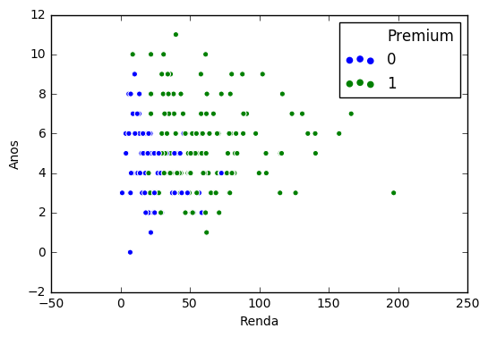

```python
import matplotlib.pyplot as plt
import seaborn as sns
import numpy as np
%matplotlib inline
sns.scatterplot(x = "Renda", y = "Anos", hue = "Premium", data = dados1)
```

## Função perda quadrática para variáveis binárias

A ideia de construir um classificador é similar ao modelo de regressão linear múltipla, ou seja, queremos minimizar uma certa distância entre os dados $y_i$ e nosso modelo linear $\beta_0 + \beta_1 renda_i + \beta_2 anos_i$. Sendo assim, uma primeira tentativa óbvia é minimizar $$ SQ(\boldsymbol{\beta}) = \sum_{i=1}^n (y_i - (\beta_0 + \beta_1 renda_i + \beta_2 anos_i))^2. $$ Isso pode ser feito facilmente em *python* uma vez que temos uma expressão fechada para os estimadores de mínimos quadrados (ordinary least squares - OLS).

```python
import statsmodels.api as sm
import statsmodels.formula.api as smf

fit_OLS = smf.ols('Premium ~ Renda + Anos', data = dados1).fit()
fit_OLS.summary()
```

OLS Regression Results

| Dep. Variable: | Premium | R-squared: | 0.360 |
| --- | --- | --- | --- |
| Model: | OLS | Adj. R-squared: | 0.353 |
| Method: | Least Squares | F-statistic: | 55.40 |
| Date: | Mon, 24 Sep 2018 | Prob (F-statistic): | 8.16e-20 |
| Time: | 18:26:29 | Log-Likelihood: | -93.537 |
| No. Observations: | 200 | AIC: | 193.1 |
| Df Residuals: | 197 | BIC: | 203.0 |
| Df Model: | 2 |  |  |
| Covariance Type: | nonrobust |  |  |

|  | coef | std err | t | P>\|t\| | [0.025 | 0.975] |
| --- | --- | --- | --- | --- | --- | --- |
| Intercept | -0.0011 | 0.082 | -0.014 | 0.989 | -0.163 | 0.161 |
| Renda | 0.0079 | 0.001 | 9.726 | 0.000 | 0.006 | 0.010 |
| Anos | 0.0485 | 0.013 | 3.609 | 0.000 | 0.022 | 0.075 |

| Omnibus: | 558.317 | Durbin-Watson: | 1.859 |
| --- | --- | --- | --- |
| Prob(Omnibus): | 0.000 | Jarque-Bera (JB): | 16.828 |
| Skew: | -0.059 | Prob(JB): | 0.000222 |
| Kurtosis: | 1.584 | Cond. No. | 178. |

Warnings:  
[1] Standard Errors assume that the covariance matrix of the errors is correctly specified.

O algoritmo convergiu e forneceu o vetor de $\beta$'s que minimiza a soma de quadrados. Podemos agora usar estes valores para predizer se um usuário é ou não premium dado sua renda e anos de experiência. Neste caso, apenas como exemplo vamos predizer os mesmos usuários que foram usados para ajustar/treinar o modelo. Note que isso, também fornece uma indicação se o modelo tem um bom poder de predição. Entretando, na prática é mais usual separar a base em treino e teste e predizer os usuários na base teste. A predição é bastante simples entramos com a renda e anos de estudo e saímos com uma predição para $y_i$. No *python* já temos funções prontas para isso, conforme abaixo.

```python
preditos = fit_OLS.get_prediction()
```

Vamos plotar os preditos contra os observados para verificar a performance do nosso modelo.

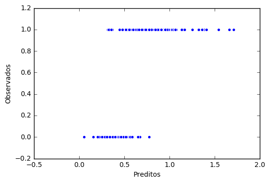

```python
sns.scatterplot(x = preditos.predicted_mean, y = dados1['Premium'])
plt.xlabel("Preditos")
plt.ylabel("Observados")
```

Apesar de ser possível essa abordagem leva a algumas incoveniências. Por exemplo, o ideal seria que as predições fossem $0$ ou $1$ refletindo se o novo usuário será ou não um assinante premium. No entanto, vimos que o modelo fornece preditos maiores que $1$ e pode potencialmente fornecer preditos negativos para usuários com pouca experiência e renda menor. Neste sentido, a interpretação do modelo não é clara e não reflete de forma fidedigna a realidade.

## Melhorando o modelo

Uma vez que nosso modelo não parece uma aproximação razoável para a realidade podemos tentar melhorá-lo fazendo com que aspectos práticos sejam levados em consideração. Note que se a previsão fosse restrita ao intervalo unitário poderíamos interpretar a previsão como uma medida de pertinência aos grupos, o que seria mais intuitivo. O que gostaríamos é que grandes valores de $ \hat{\beta}_0 + \hat{\beta}_1 renda_i + \hat{\beta}_2 anos_i$ resultassem em valores próximos a $1$. Da mesma forma, pequenos valores de $ \hat{\beta}_0 + \hat{\beta}_1 renda_i + \hat{\beta}_2 anos_i$ devem resultar em valores próximos a $0$. Para incluir em nosso modelo essa intuição podemos usar uma função matemática que tenha essa característica. O que precisamos é uma função que receba um número real qualquer e resulte em um número no intervalo unitário. Em outros termos, precisamos de uma função que tenha domínio sendo os números reais e como imagem o intervalo unitário, ou seja, $f(\cdot): \Re \to (0,1)$.

Existem na literatura diversas funções que tem tal propriedade. Uma escolha popular é a função logística dada por: $$ f(x) = \frac{1}{1+e^{-x}}, $$ cujo gráfico é apresentado abaixo.

```python
import numpy as np

def logit(x):
    output = 1/ (1+ np.exp(-x))
    return output
```

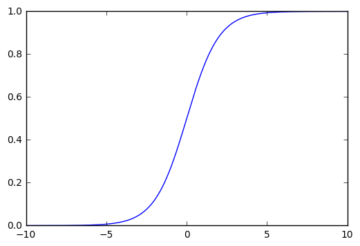

```python
grid = np.linspace(start = -10, stop = 10, num = 1000)
plt.plot(grid,logit(grid))
```

Com a função logística em mãos podemos rescrever nossa função objetivo como

$$ SQ_{logit}(\boldsymbol{\beta}) = \sum_{i=1}^n \left(y_i - \frac{1}{(1+ e^{-(\beta_0 + \beta_1 renda_i + \beta_2 anos_i)} )} \right)^2. $$

Novamente, precisamos otimizar essa função objetivo, ou seja, encontrar $\beta_0$, $\beta_1$ e $\beta_2$ que tornam $SQ_{logit}$ o menor possível. Neste caso, não temos uma expressão fechada para os estimadores de $\beta_0$ e $\beta_1$. Sendo assim, precisamos obter tais valores numéricamente. O python oferece um grande conjunto de otimizadores numéricos através do módulo scipy.optimize. Para isto, primeiro precisamos escrever a função a ser minimizada.

```python
def model_logit(par, y, renda, ano):
    predito = 1/ (1 + np.exp(- (par[0] + par[1]*renda + par[2]*ano)))
    output = sum(np.power( (y - predito), 2))
    return output
```

Minimizando a função objetivo, usando minimizador numérico.

```python
from scipy.optimize import minimize
par = np.array([-1,0,0])
res1 = minimize(model_logit, par, method = 'BFGS', args = (dados1['Premium'], dados1['Renda'], dados1["Anos"]))
print(res1.x) # Valores de b0, b1 e b2
print(res1.fun) # Valor minimizado da funçao perda
```

```
[-6.63816742  0.12842839  0.53862841]
21.357873625896957
```

Plotando os preditos contra os observados.

```python
res1.x[0]
```

```
-6.6381674243391782
```

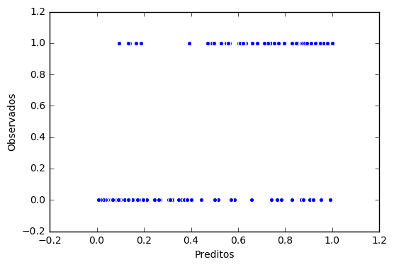

```python
eta = res1.x[0] + res1.x[1]*dados1['Renda'] + res1.x[2]*dados1['Anos']
pred = 1/(1+np.exp(-eta))
sns.scatterplot(x = pred, y = dados1['Premium'])
plt.xlabel("Preditos")
plt.ylabel("Observados")
```

Neste caso fica claro que nosso modelo só prediz valores no intervalo unitário como gostaríamos. Claramente quanto maior é o preditor maior é a chance dos observados serem $1$ como queríamos.

## Melhorando a função objetivo

Apesar de melhor que a estratégia anterior, essa abordagem ainda faz uso uso da perda quadrática. Isso significa assumimos que nossos erros são simétricos ao redor da curva ajustada, neste caso a logística. Entretanto, tal suposição não reflete o fato de que nas caudas da curva os erros não podem ser simétricos. Por exemplo, no extremo da cauda esquerda (baixa renda e pouca experiência) só podemos errar para mais, enquanto que no extremo da cauda direita só podemos errar para menos. Assim, seria interessante termos uma função objetivo que melhor represente nossa intuição.

Para construir uma função objetivo que atenda a nossa intuição, podemos recorrer a uma distribuição de probabilidade adequada para dados binários. A distribuição Bernoulli modela variáveis aleatórias que podem assumir apenas dois valores $0$ ou $1$, sendo $1$ chamado de sucesso e $0$ de fracasso. A distribuição Bernoulli, tem a seguinte função de probabilidade $$ P(Y = y_i) = p^{y_i}(1-p)^{1-y_i}, $$ onde $p$ é a probabilidade de sucesso, ou seja, $P(Y = 1) = p$.

Para um conjunto de $n$ observações cada uma sendo binária, podemos usar o produto das funções de probabilidade como uma função objetivo a ser maximizada neste caso. Note que a função de probabilidade fornece a probabilidade da variável aleatória assumir um certo valor dado um valor para $p$. Uma vez que temos os dados observados $y_i$ a única quantidade desconhecida é o valor de $p$. E a nossa função objetivo fornece a probabilidade de observar os dados REALMENTE observados $y_i$ caso o valor do $p$ seja um valor fixado. O objetivo é encontrar $\hat{p}$ que maximiza essa probabilidade, ou seja, de observar o que você REALMENTE observou. Essa é a idéia por traz de um dos métodos mais populares e poderosos de estimação chamado método de máxima verossimilhança que vamos ver no decorrer do curso.

Como $p$ é a probabilidade de sucesso, neste caso o usuário ser assinante \textit{premium}, podemos descrever tal probabilidade de acordo com as características dos usuários, neste caso renda e anos de experiência. Uma vez que $p$ é uma probabilidade só pode assumir valores no intervalo unitário, assim usando a função logística podemos descrever/modelar $p$ pela seguinte equação:

$$ p_i = \frac{1}{1+e^{-(\beta_0 + \beta_1 renda_i + \beta_2 anos)}}. $$

Substituindo na equação acima chegamos a seguinte função objetivo $$ L(\boldsymbol{\beta}) = \prod_{i=1}^n p_i^{y_i}(1-p_i)^{1-y_i}. $$

Entretanto, em termos computacionais usar o produto de números entre $0$ e $1$ é incoveniente, porque conforme o número de termos sendo multiplicado cresce a função objetivo vai rapidamente para zero. Assim, é mais conveniente computacionalmente usar o logaritmo do produto das funções de probabilidade o que resulta na seguinte função objetivo: $$ l(\boldsymbol{\beta}) = \sum_{i=1}^n y_i \log(p_i) + (1-y_i)\log(1-p_i). $$

Essa função objetivo reflete o fato dos erros não serem simétricos ao redor do modelo ajustado e na sequência vamos ver como também fornece uma série de propriedades interessantes do ponto de vista de estatística.

Para finalizar, vamos implementar essa nova função objetivo e otimizá-la numéricamente. A função em *python* fica dada por

```python
def reg_logit(par, y, renda, ano):
    p = 1/ (1 + np.exp(- (par[0] + par[1]*renda + par[2]*ano)))
    output = -sum(y*np.log(p) + (1-y)*np.log(1-p))
    return output
```

```python
par = np.array([-1,0,0])
res2 = minimize(reg_logit, par, method = 'Nelder-Mead', args = (dados1['Premium'], dados1['Renda'], dados1["Anos"]))
print(res2.x) # Valores de b0, b1 e b2
print(res2.fun) # Valor minimizado da funçao perda
```

```
[-6.12216576  0.11253476  0.50422849]
68.0793684295
```

Note que neste caso temos que maximizar a função objetivo, por isso multiplicamos a função objetivo por $-1$ para tornar o problema de minimização, uma vez, que por *default* a função *minimize()* minimiza a função objetivo. O modelo apresentado é o que chama-se popularmente de regressão logística e encontra-se implementado na biblioteca stats.models.

```python
import statsmodels.api as sm
import statsmodels.formula.api as smf
results = sm.GLM(endog = dados1['Premium'], exog = sm.add_constant(dados1[['Renda','Anos']]),
                 family = sm.families.Binomial()).fit()
results.summary()
```

Generalized Linear Model Regression Results

| Dep. Variable: | Premium | No. Observations: | 200 |
| --- | --- | --- | --- |
| Model: | GLM | Df Residuals: | 197 |
| Model Family: | Binomial | Df Model: | 2 |
| Link Function: | logit | Scale: | 1.0000 |
| Method: | IRLS | Log-Likelihood: | -68.079 |
| Date: | Mon, 24 Sep 2018 | Deviance: | 136.16 |
| Time: | 19:32:55 | Pearson chi2: | 187. |
| No. Iterations: | 7 | Covariance Type: | nonrobust |

|  | coef | std err | z | P>\|z\| | [0.025 | 0.975] |
| --- | --- | --- | --- | --- | --- | --- |
| const | -6.1222 | 1.033 | -5.927 | 0.000 | -8.147 | -4.098 |
| Renda | 0.1125 | 0.017 | 6.673 | 0.000 | 0.079 | 0.146 |
| Anos | 0.5042 | 0.125 | 4.033 | 0.000 | 0.259 | 0.749 |

Note que o resultado da função sm.GLM() retorna exatamente o que já haviamos obtido numericamente, usando a função minimize. Porém, agora temos os erros padrões, bem como, estatísticas Z, p-valores e intervalos de confiança associados a cada um dos coeficientes de regressão do modelo de regressão logística.

Note que ambas covariáveis são significativas, ou seja, tem informação para explicar o comportamento da variável resposta. Da mesma forma que fizemos com o modelo de regressão linear múltipla podemos obter valores preditos e interpretar os coeficientes de regressão. Note que a saída de um GLM (Generalized Linear models) não é tão rica quanto a saída do OLS. Isso se deve ao fato da biblioteca statsmodels estar ainda em desenvolvimento e os métodos para GLMs ainda são escassos.